# stepik_report_3

Alona Sychevska

10/10/2019

```r
library(lattice)
library(psych)
library(ggplot2)
library(qqplotr)
library(GGally)
library(Rmisc)
library(ggpubr)
```

## Задача по программированию на R

Задача: проверить Центральную предельную теорему для любимого дискретного распределения.

План:

1. Выбирите ваше любимое дискретное распределение. Например, можете выбрать распределение из этого списка: Бернулли, биномиальное, равномерное (кубик), Пуассон, геометрическое распределение.

Я выбрала биномиальное распределение.

2. Узнайте, как в R извлечь выборку из вашего любимого распределения. Нужная вам функция должна начинаться на букву r (например, runif, rbinom, ..)

С биномиального распределения выборку можно извлечь при помощи функции rbinom.

3. Извлеките 3 выборки из вашего распределения размером 10, 100, 1000 и постройте для них гистограммы. Похожи ли эти гистограммы на теоретическое распределение?

Чем больше обьем выборки, тем больше распределение начинает напоминать биномиальное.

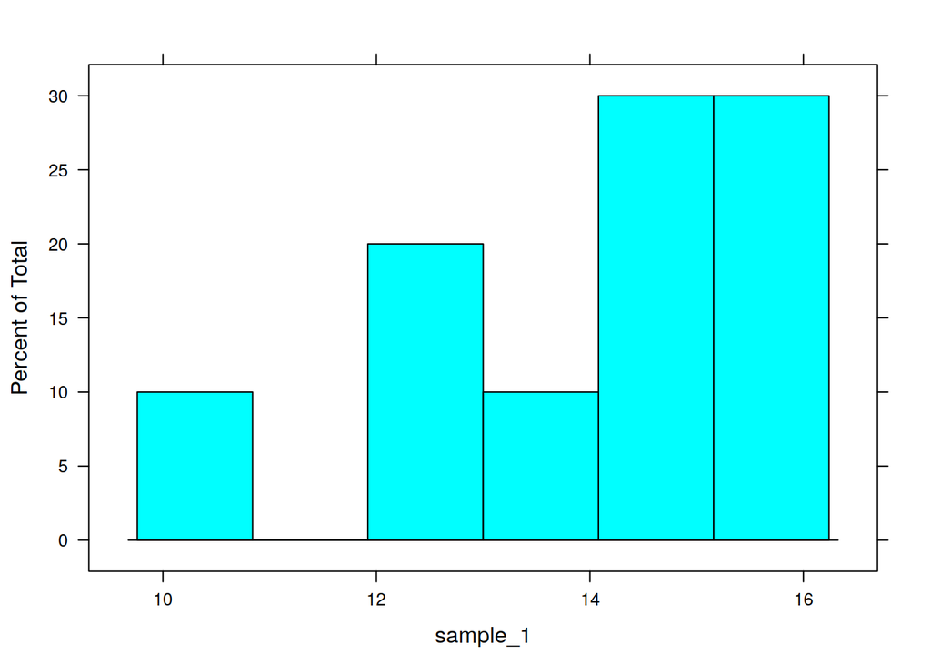

```r
p <- 0.7 #  вероятность успеха в эксперименте Бернулли;
n <- 20 # количество бросков в биномиальном эксперименте;

sample_1 <- rbinom(n = 10, size = n, prob = p)
sample_2 <- rbinom(n = 100, size = n, prob = p)
sample_3 <- rbinom(n = 1000, size = n, prob = p)

#library(ggplot2)
#ggplot(as.numeric(sample_1)) + geom_histogram(binwidth = n)

histogram(sample_1, nint=length(unique(sample_1)))
```

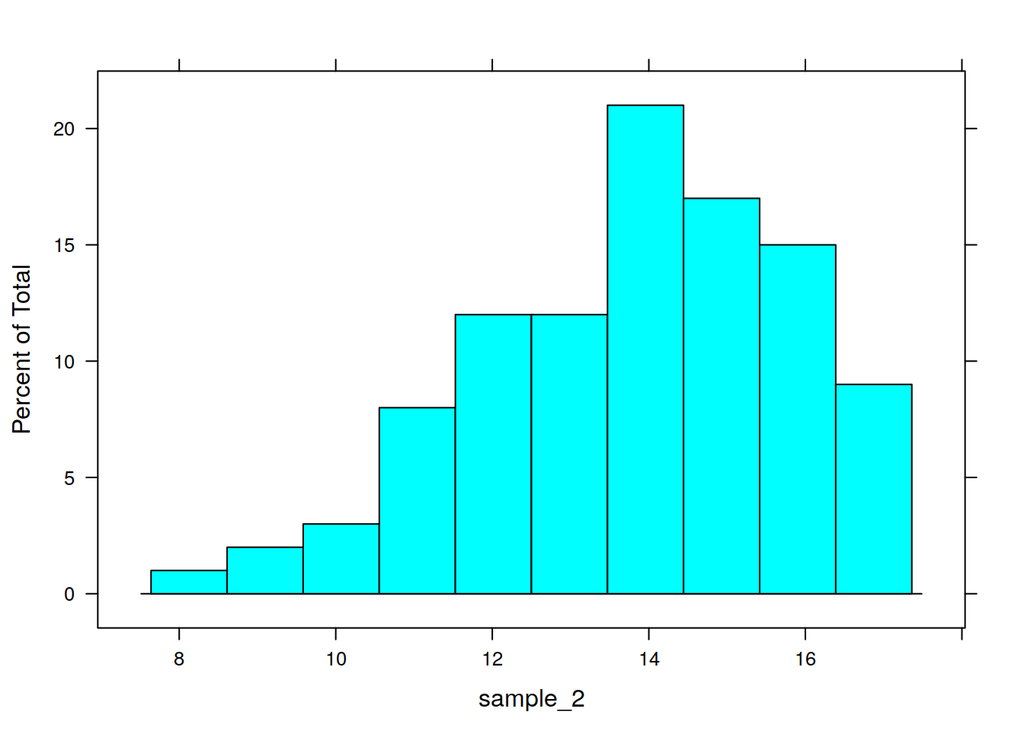

```r
histogram(sample_2, nint=length(unique(sample_2)))
```

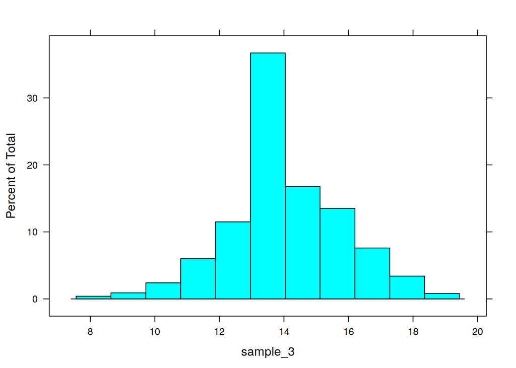

```r
histogram(sample_3)
```

5. Используйте векторизованную функцию replicate (посмотрите самостоятельно, что она делает), чтобы создать 1000 выборок, каждая из которых имеет размер 10

```r
samples <- replicate(1000, rbinom(n=10, size = n, prob = p))
```

6. Используйте функцию apply, чтобы посчитать вектор средних значений

```r
apply(X = samples, MARGIN = 2, FUN = mean)
```

[output not shown]

[output cut: 57 more lines]

7. Оберните шаги 5-6 в функцию, которая принимает объем выборки и возвращает вектор средних значений

```r
CLT_saples_mean <- function(sample_size){
  samples <- replicate(1000, rbinom(n=sample_size, size = n, prob = p))
  apply(X = samples, MARGIN = 2, FUN = mean)
}
```

8. Постройте гистограммы средних для разных объемов выборки – 2, 5, 30, 100, 1000

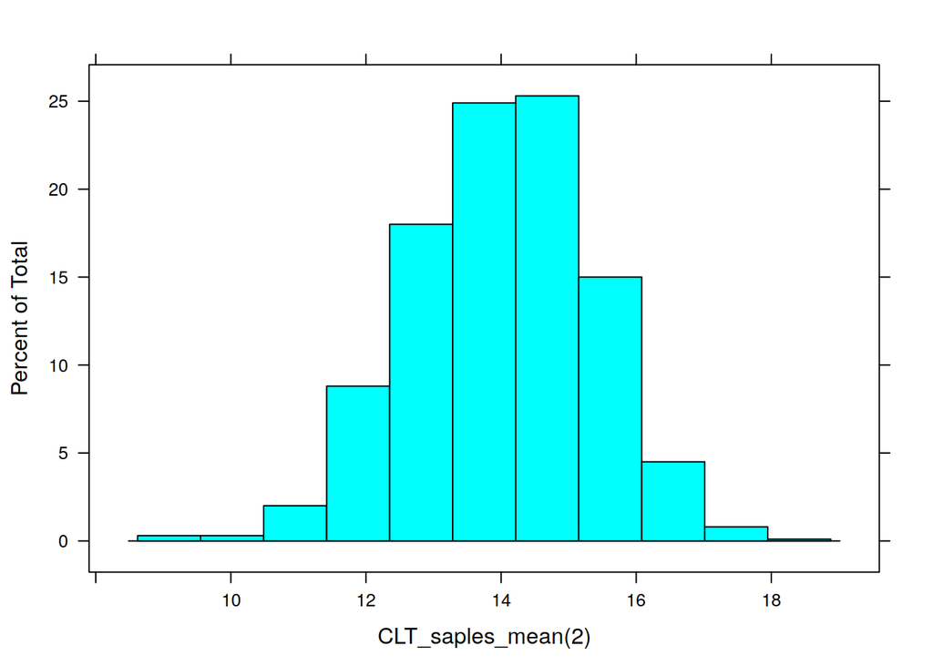

```r
histogram(CLT_saples_mean(2))
```

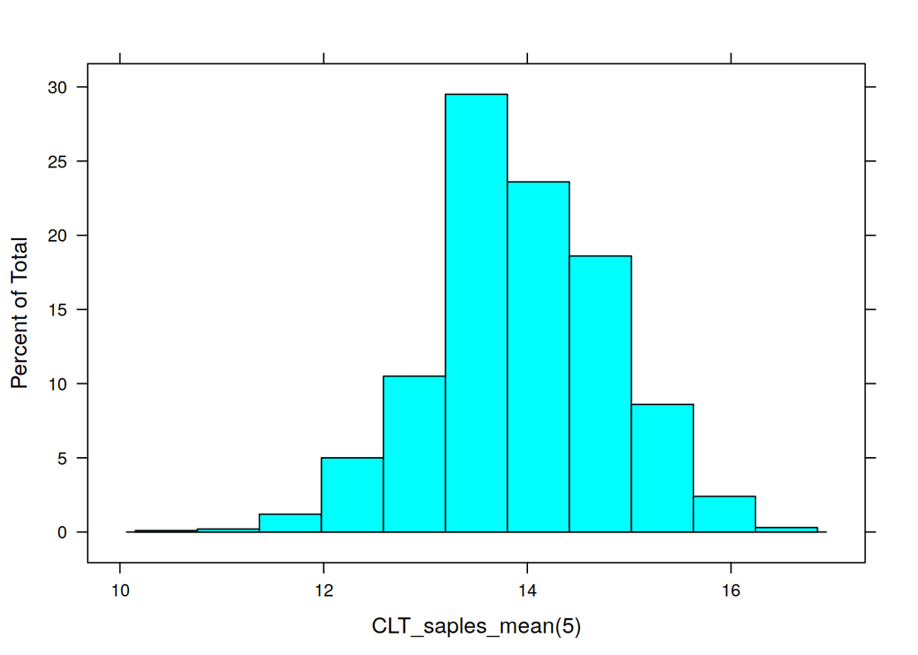

```r
histogram(CLT_saples_mean(5))
```

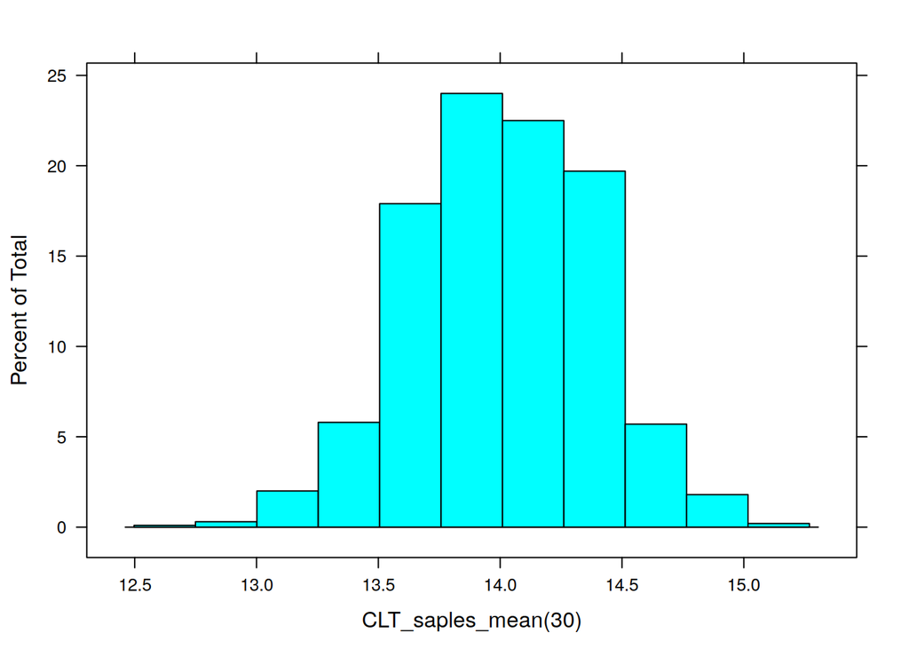

```r
histogram(CLT_saples_mean(30))
```

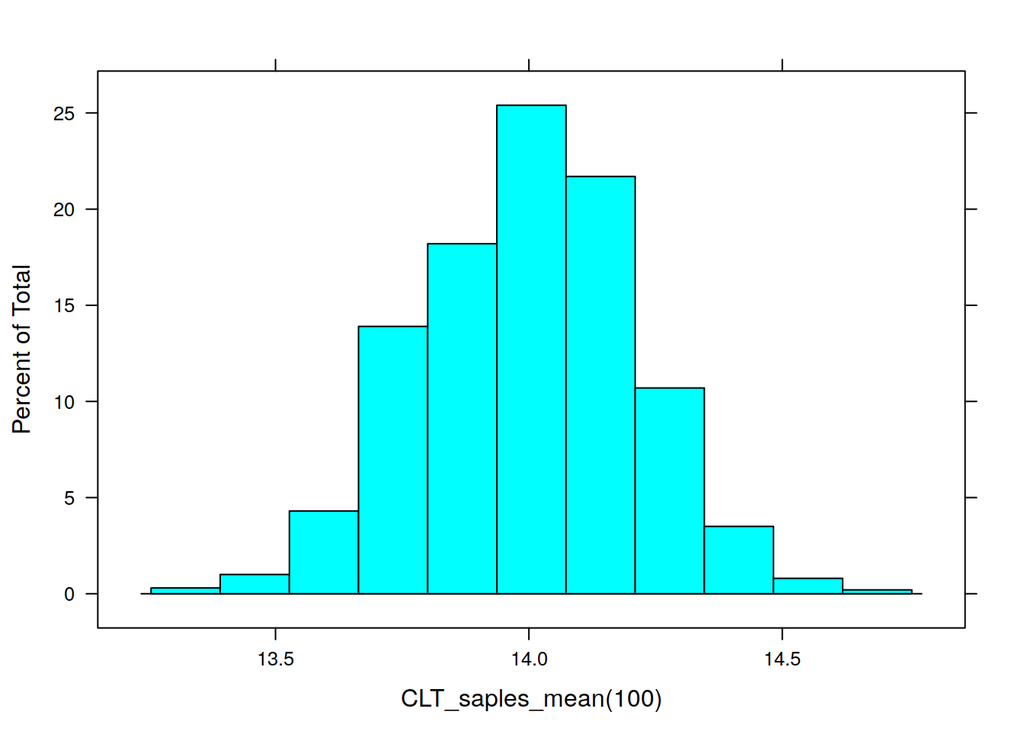

```r
histogram(CLT_saples_mean(100))
```

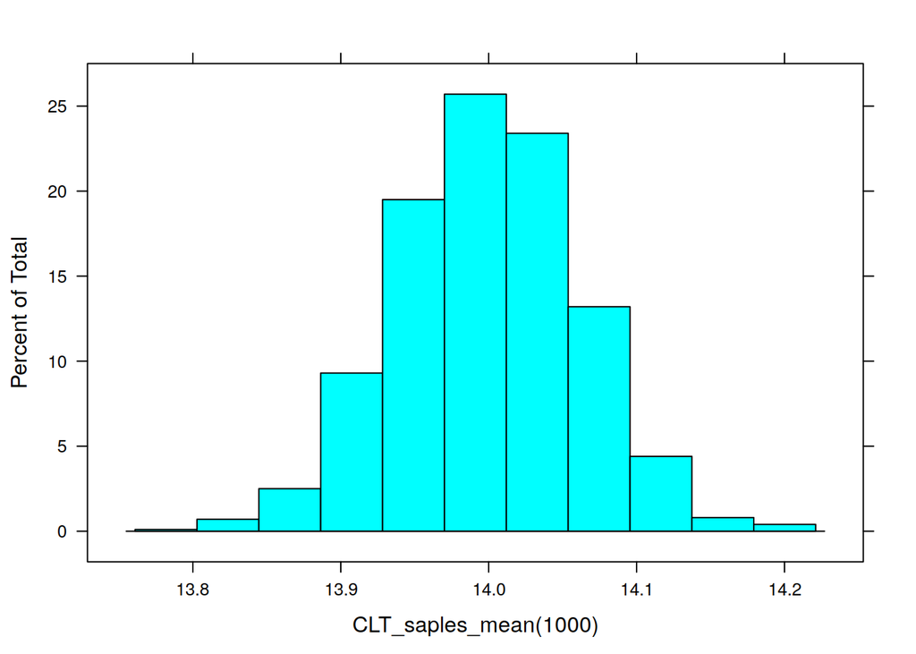

```r
histogram(CLT_saples_mean(1000))
```

9. Что вы видите на этих гистограммах? Совпадает ли это с тем, что говорит ЦПТ? Расскажите свои наблюдения.

Чем больше обьем выборки, тем меньше стандартная ошибка среднего. Распределение выглядит, как нормальное при больших n.

## Задание по анализу данных:

Продолжаем работать с датасетом heart. В этот раз ваша задача состоит в том, чтобы проанализировать распределение признаков на нормальность и построить доверительные интервалы.

```r
# Загрузка данных

heart_data <- read.csv("~/code/scripts/R/stepik_projects/heart.csv")

# Работа с пропущенными значениями
#Я решила удалить строки с пропущенными значениями, так как данных для анализа достаточно

heart_data$ca[heart_data$ca == "?"] <- NA
heart_data$thal[heart_data$thal == "?"] <- NA

heart_data <- na.omit(heart_data)

# Изменение типов переменных
#Я решила изменить тип некоторых переменных и изменить их levels, так как в даном дата фрейме много векторов с качественными признаками

heart_data$sex <- factor(heart_data$sex)
levels(heart_data$sex) <- c("female", "male")

heart_data$cp <- factor(heart_data$cp)
levels(heart_data$cp) <- c("typical","atypical","non-anginal","asymptomatic")

heart_data$fbs <- factor(heart_data$fbs)
levels(heart_data$fbs) <- c("false", "true")

heart_data$restecg <- factor(heart_data$restecg)
levels(heart_data$restecg) <- c("normal","stt","hypertrophy")

heart_data$exang <- factor(heart_data$exang)
levels(heart_data$exang) <- c("no","yes")

heart_data$slope <- factor(heart_data$slope)
levels(heart_data$slope) <- c("upsloping","flat","downsloping")

heart_data$ca <- factor(heart_data$ca) # не делаем конвертацию, так как это не обязательно;

heart_data$thal <- factor(heart_data$thal)
levels(heart_data$thal) <- c("normal","fixed","reversable")


heart_data$num <- ifelse(heart_data$num %in% c(0), 0, 1)

heart_data$num <- factor(heart_data$num)
levels(heart_data$num) <- c("Здоров", "Болен")
```

1. Для каждого количественного признака* постройте QQ-плот

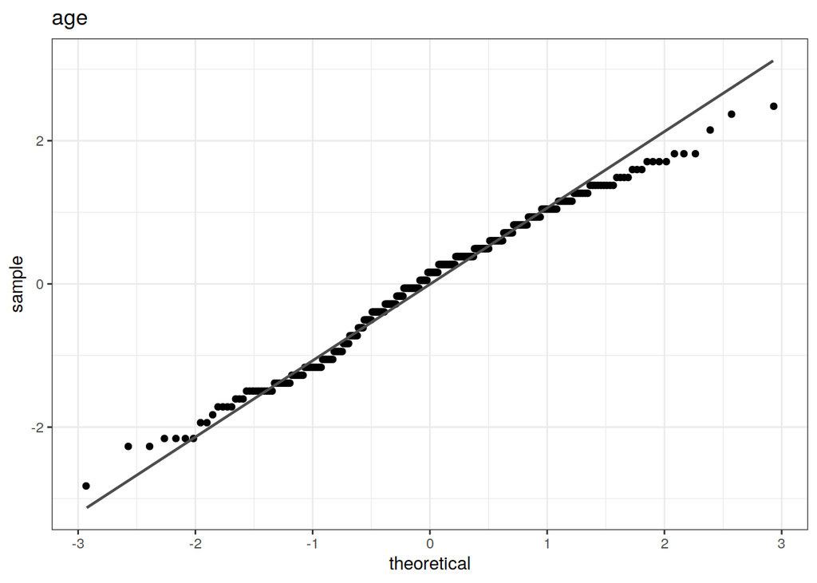

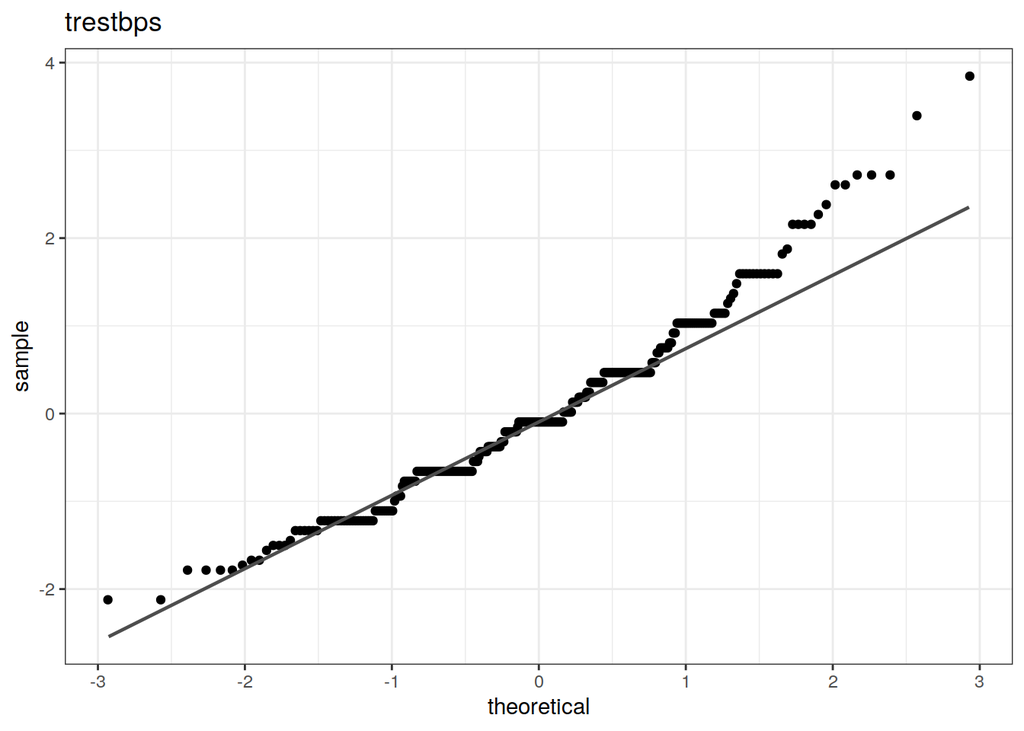

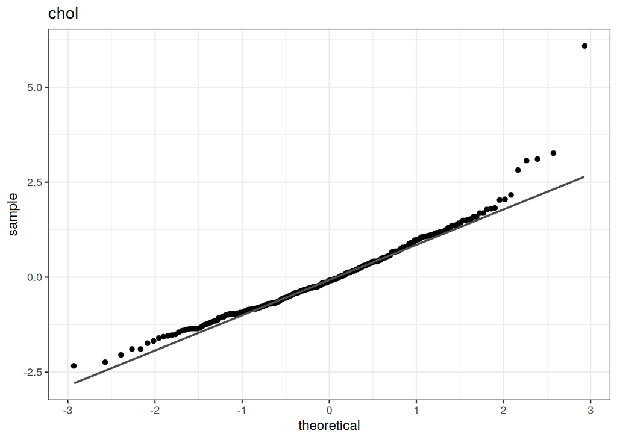

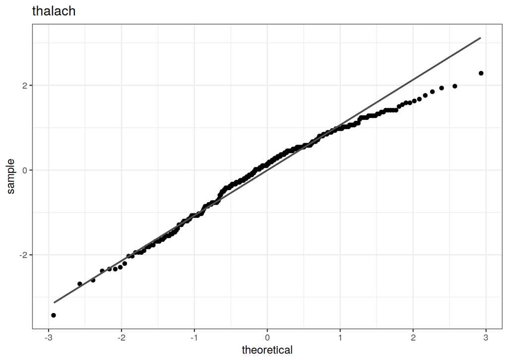

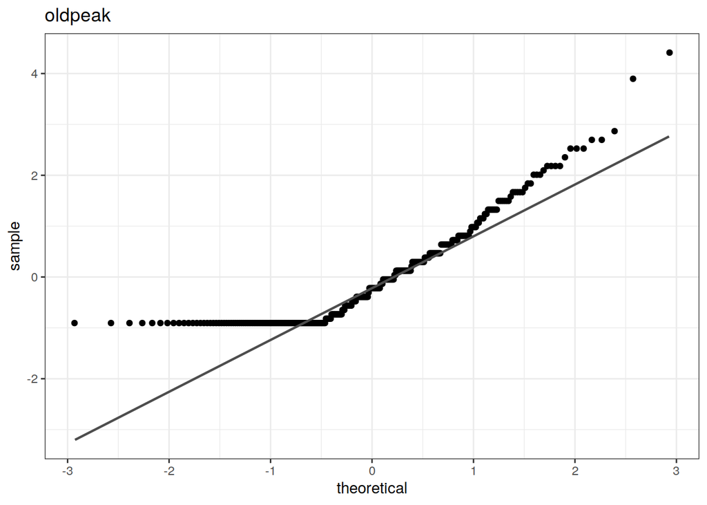

```r
sapply(colnames(heart_data), function(col) {
  data <- heart_data[, col]
  if (is.numeric(data)) {
    ggplot() + aes(sample = scale(data)) +
      stat_qq() +
      stat_qq_line() +
      ggtitle(col)+
      theme_bw()
  }
})
```

2. Опишите каждый QQ-плот: толстые хвосты, тонкие хвосты, перекосы влево-вправо, …

#Age

Наблюдаем тонкие хвосты. Распределение выглядит близким к нормальному, но с видимими регулярными отклонениями. Существует выпуклость около -1 sigma.

#trestbps

Толстый хвост справа. Ступеньки непонятной природы. Слева возможный тонкий хвост (?)

#chol

Слева тонкий хвост (?). Справа толстый хвост (?) и аутлаер. Горбик в правой части распредления.

#thalach

Тонкий правый хвост.

#oldpeak

Не нормальное распределение.

3. Если вы видите у распределения тяжелый хвост справа, то попробуйте это признак логарифмировать и снова построить QQ-плот. Стало ли лучше?

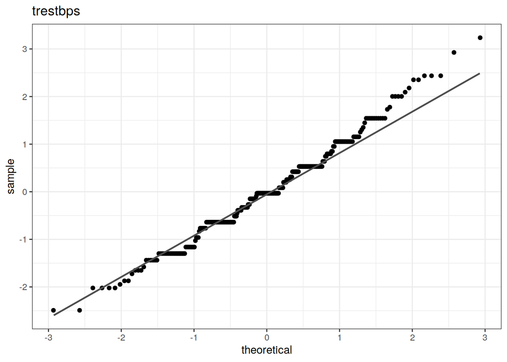

```r
log_qqplot <- function(col) {
  ggplot() + aes(sample = scale(log(heart_data[, col]))) +
    stat_qq() +
    stat_qq_line() +
    ggtitle(col) +
    theme_bw()
}

log_qqplot("trestbps")
```

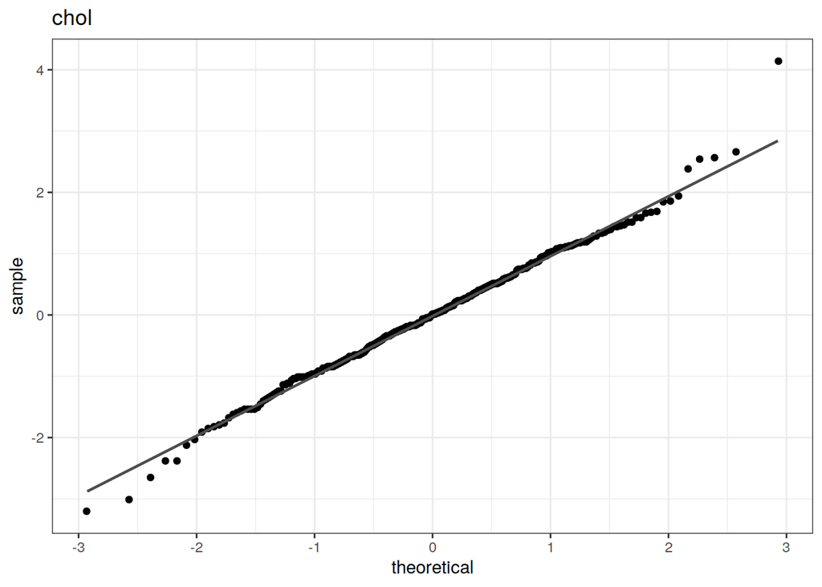

```r
log_qqplot("chol")
```

4. Если признак плохо ложится на прямую в QQ-плоте, то попробуйте разбить его по категориальным переменным (м-ж, болен-здоров) и посмотреть на QQ-плоты для каждой подгруппы. Может оказаться так, что только какая-то определенная группа плохая.

В распределении по переменной trestbps, разбитом по болен-здоров, распределение для здоров выглядит более нормально.

Для других переменных явных отличий нету.

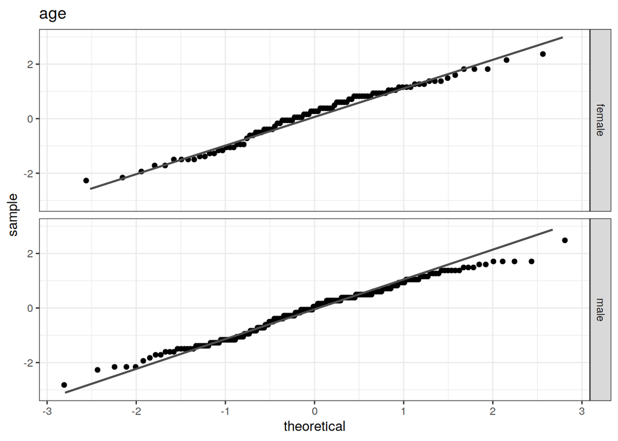

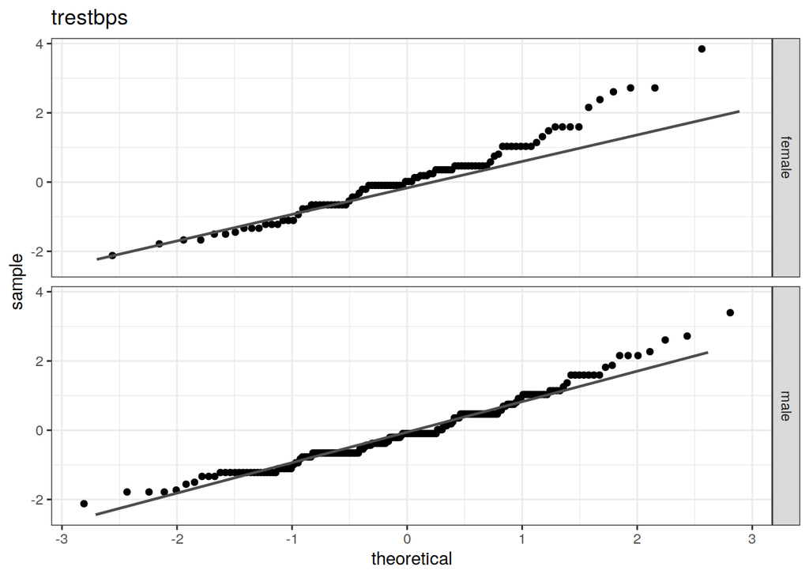

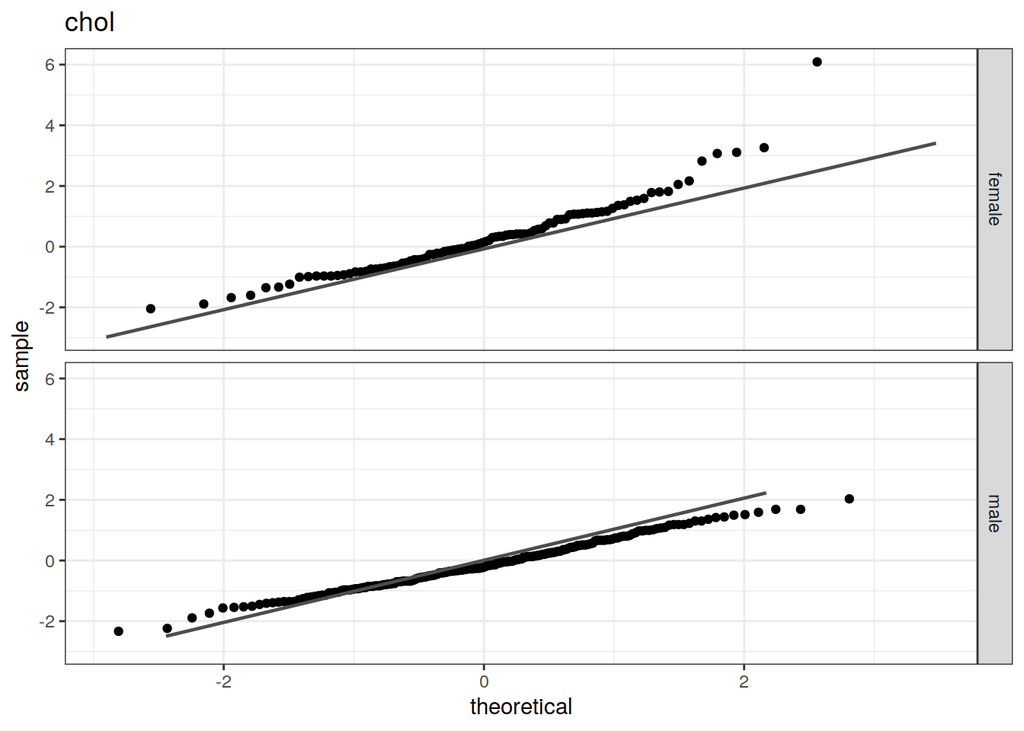

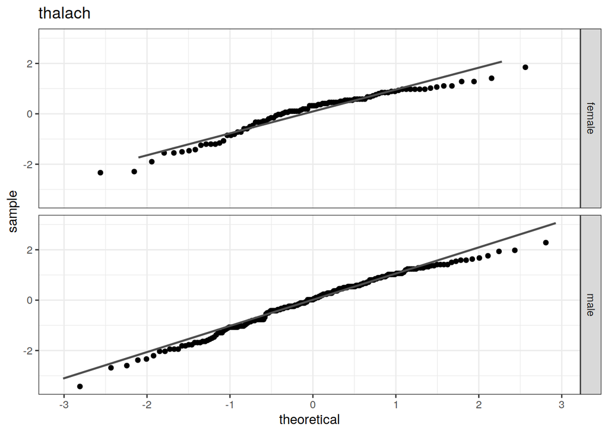

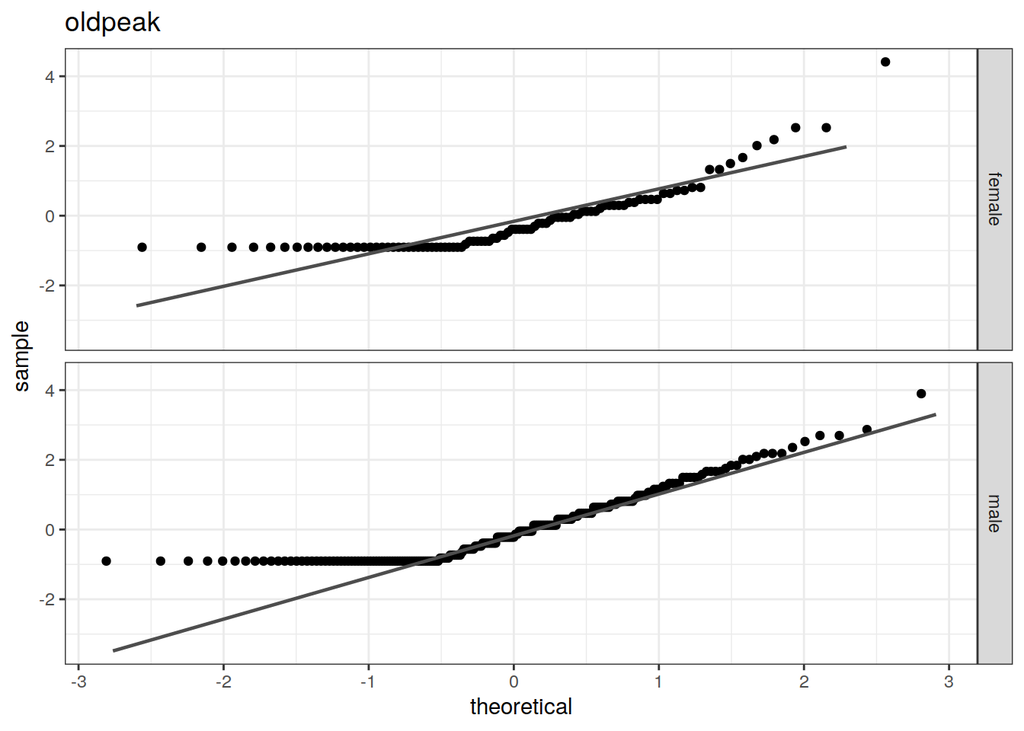

```r
sapply(colnames(heart_data), function(col) {
  data <- heart_data[, col]
  if (is.numeric(data)) {
    ggplot(heart_data) + aes(sample = scale(data)) +
      stat_qq() +
      stat_qq_line() +
      facet_grid(sex ~.) +
      ggtitle(col)+
      theme_bw()
  }
})
```

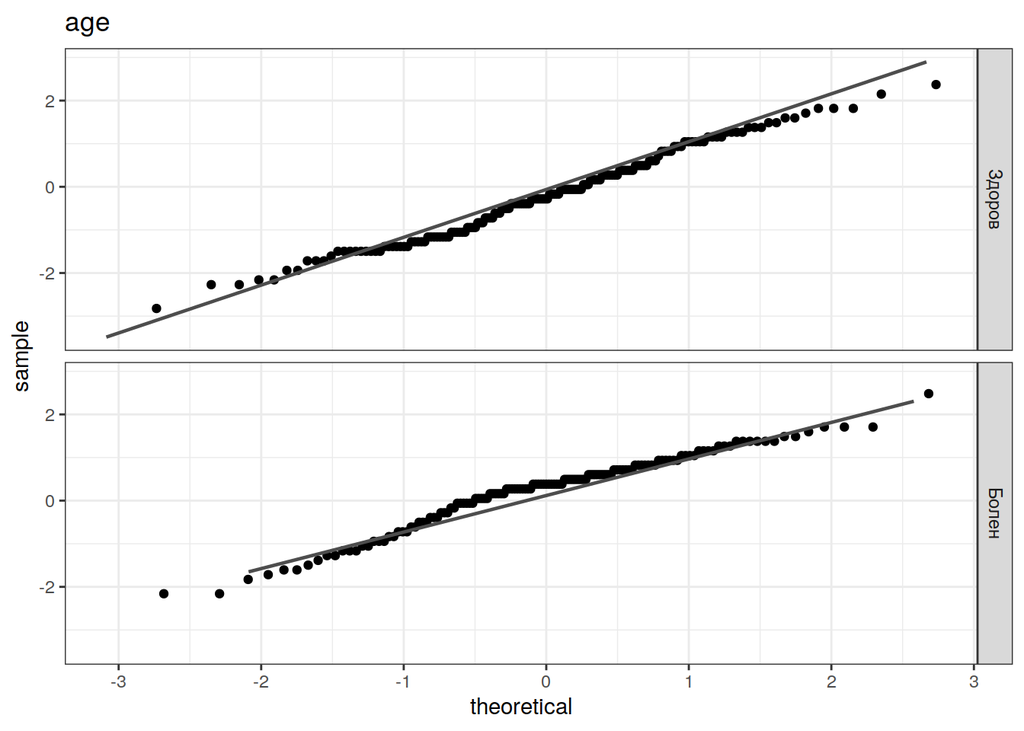

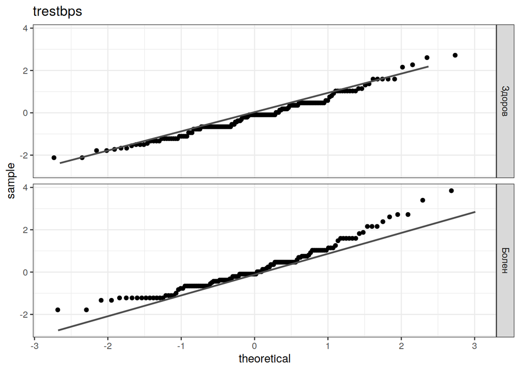

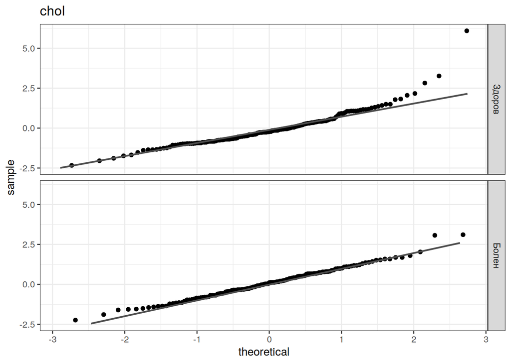

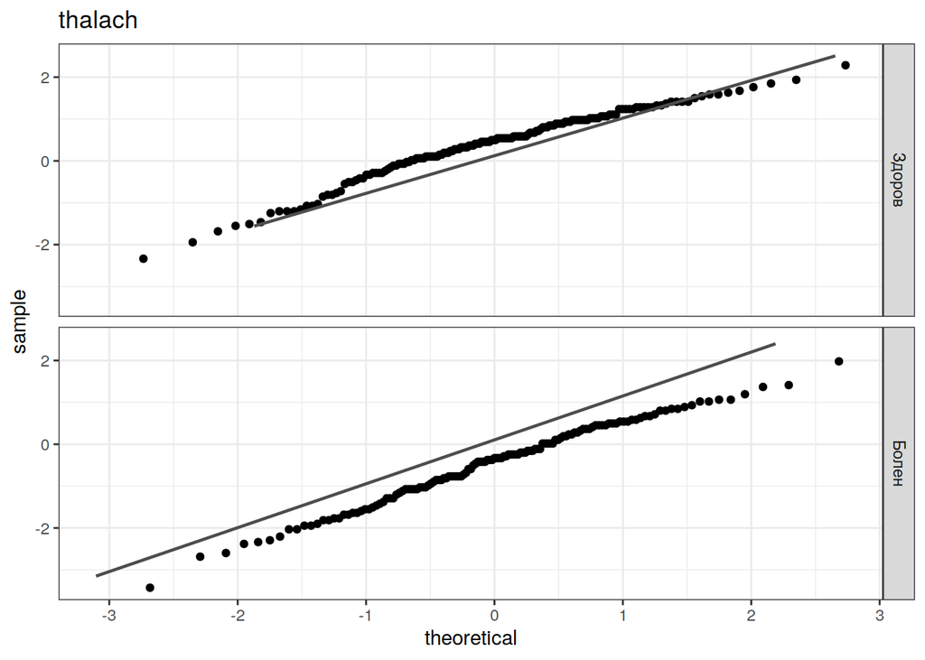

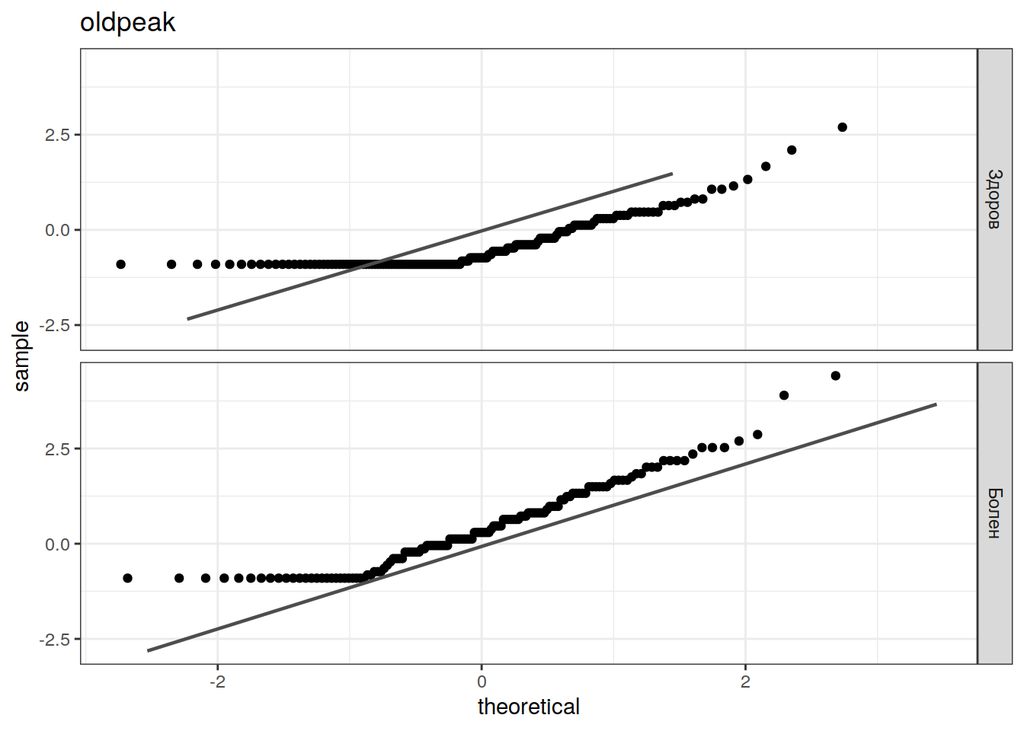

```r
sapply(colnames(heart_data), function(col) {
  data <- heart_data[, col]
  if (is.numeric(data)) {
    ggplot(heart_data) + aes(sample = scale(data)) +
      stat_qq() +
      stat_qq_line() +
      facet_grid(num ~.) +
      ggtitle(col)+
      theme_bw()
  }
})
```

5. Постройте доверительные интервалы с помощью функции CI для всех количественных переменных

```r
sapply(colnames(heart_data), function(col) {
  data <- heart_data[, col]
  if (is.numeric(data)) {
    CI(heart_data[, col], ci = 0.95)
      }
})
```

```
## $age
##    upper     mean    lower
## 55.57553 54.54209 53.50865
##
## $sex
## NULL
##
## $cp
## NULL
##
## $trestbps
##    upper     mean    lower
## 133.7220 131.6936 129.6652
##
## $chol
##    upper     mean    lower
## 253.2881 247.3502 241.4123
##
## $fbs
## NULL
##
## $restecg
## NULL
##
## $thalach
##    upper     mean    lower
## 152.2192 149.5993 146.9795
##
## $exang
## NULL
##
## $oldpeak
##     upper      mean     lower
## 1.1887216 1.0555556 0.9223895
##
## $slope
## NULL
##
## $ca
## NULL
##
## $thal
## NULL
##
## $num
## NULL
```

6. Постройте доверительные интервалы самостоятельно с помощью формулы (не забудьте объяснить, почему в нашем случае корректно использовать эту формулу).

```r
sapply(colnames(heart_data), function(col) {
  data <- heart_data[, col]
  if (is.numeric(data)) {
    mu_col <- mean(data)
    se <- sd(data)/sqrt(pairwiseCount(data))
    lower_CI <- mu_col - 1.96 * se
    upper_CI <- mu_col + 1.96 * se
    print(c(lower_CI, mu_col, upper_CI))
   }
})
```

```
## [1] 53.51285 54.54209 55.57132
## [1] 129.6734 131.6936 133.7138
## [1] 241.4364 247.3502 253.2639
## [1] 146.9902 149.5993 152.2085
## [1] 0.9229316 1.0555556 1.1881796
```

```
## $age
## [1] 53.51285 54.54209 55.57132
##
## $sex
## NULL
##
## $cp
## NULL
##
## $trestbps
## [1] 129.6734 131.6936 133.7138
##
## $chol
## [1] 241.4364 247.3502 253.2639
##
## $fbs
## NULL
##
## $restecg
## NULL
##
## $thalach
## [1] 146.9902 149.5993 152.2085
##
## $exang
## NULL
##
## $oldpeak
## [1] 0.9229316 1.0555556 1.1881796
##
## $slope
## NULL
##
## $ca
## NULL
##
## $thal
## NULL
##
## $num
## NULL
```

7. Сравните результаты ваших доверительных интервалов и функции CI. Совпадают ли они? Если нет, то разберитесь, кто из вас неправ :)

Как видно, после использования функции CI и после подсчета доверительных интервалов вручную, минимальное, среднее и максимальное значения совпадают.

8. Постройте графики доверительных интервалов для всех количественных переменных с разделением по болен-здоров. Видите ли вы непересекающиеся доверительные интервалы?

Да, можно заметить непересекающиеся доверительные интервалы по переменных age, thalach и oldpeak.

#age

Возраст статистически значимо влияет на распредление на больных и здоровых.

#thalach

У больных людей сердечный ритм во время максимальной нагрузки ниже, со статистической значимостью 95%.

#oldpeak

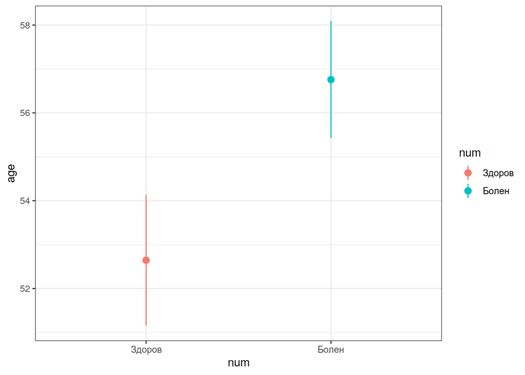

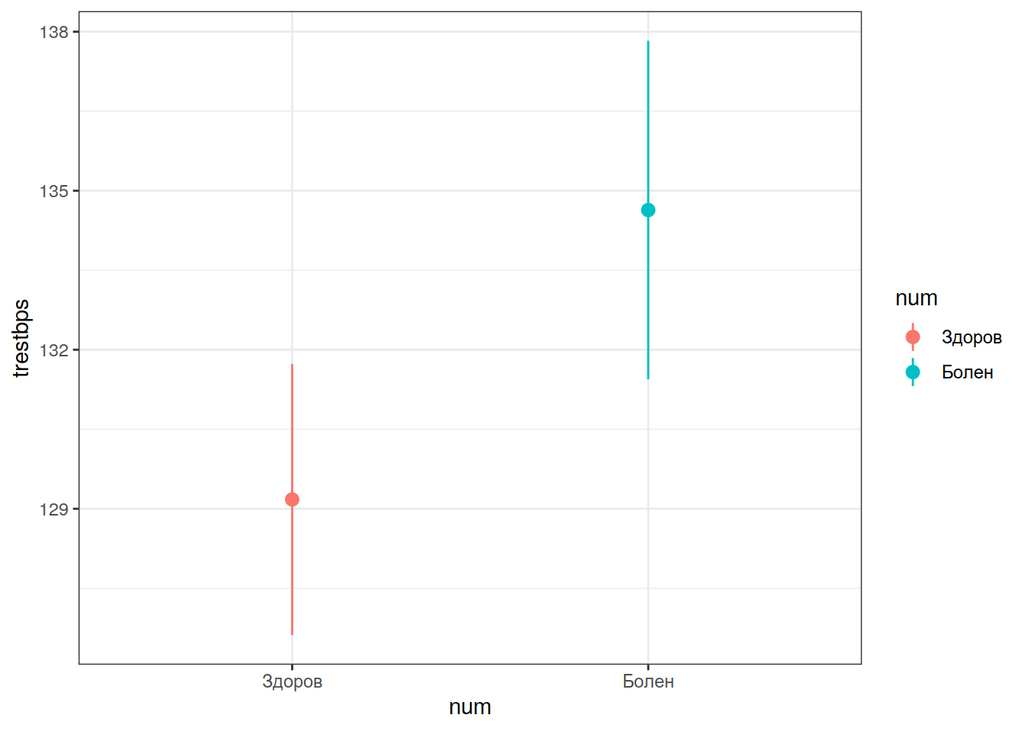

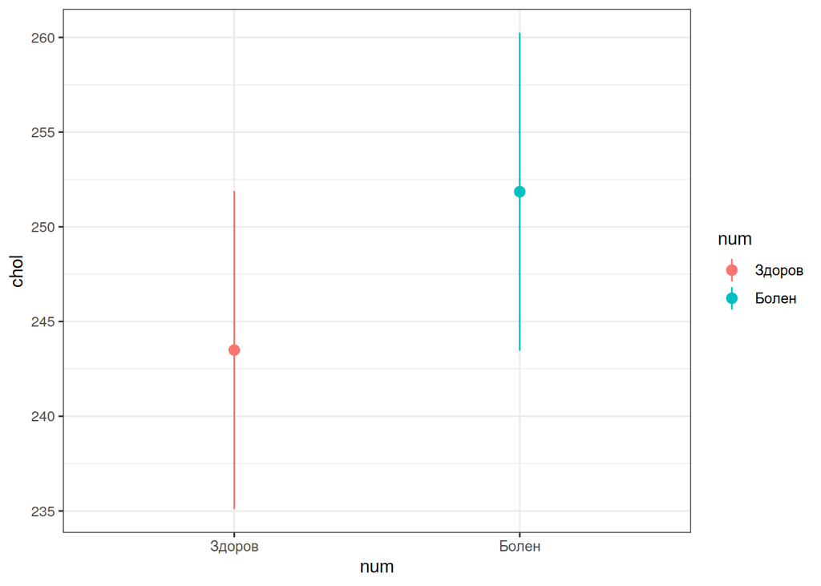

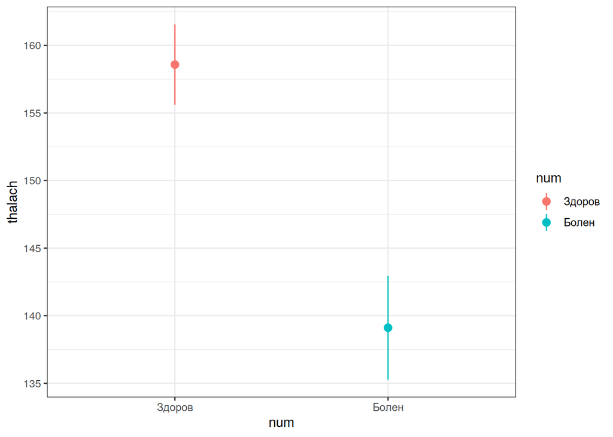

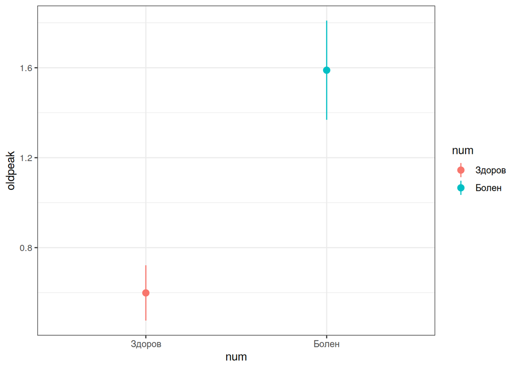

```r
sapply(colnames(heart_data), function(col) {
  data <- heart_data[, col]
  if (is.numeric(data)) {
    ggerrorplot(heart_data,
      x = "num", y = col,
      desc_stat = "mean_ci", ci = 0.95,
      color = "num") +
      theme_bw()
  }
})
```

```r
#ggdensity(heart_data, x = "age",
#   add = "mean", rug = TRUE,
#   color = "num", fill = "num",
#   palette = c("#00AFBB", "#E7B800"))
```

*Бонусное задание: попробуйте сделать так, чтобы графики для всех переменных построились автоматически. Особенно это удобно, если количественных переменных в датасете очень много